# Results of a Community Mental Health Assessment in Lira District, Northern Uganda

Author

Kyra Guy

#### Introduction

The political history of Lira District, the epicenter of the decades-long conflict between the Lord's Resistance Army (LRA) and the Ugandan government, makes for an especially interesting case study of the political and social determinants of mental health of those directly impacted by conflict, and generations growing up in post-conflict communities. Data collected by this study aimed to evaluate the current mental health outcomes of adolescents (14-17 years of age). This dataset has been used previously for other analyses and was submitted for publication in the journal Conflict and Health, published by the British Medical Journal.

Data was collected through an adolescent questionnaire assessing general demographics, physical health status, diet, substance use, violence and risky behaviors, mental health knowledge, and behaviors, Adverse Childhood Experiences Score (ACE-IQ), and WHO-5 Wellbeing Index Scores. Used consistently in research, the ACE-IQ survey is intended to measure some of frequently occurring sources of stress that children may suffer early in life. Questions cover family dysfunction; physical, sexual and emotional abuse and neglect by parents or caregivers; peer violence; witnessing community violence, and exposure to collective violence. Scores have been used as general predictors of future adolescent health outcomes. The WHO Wellbeing Index scores are measured out of 100 and assess current adolescent states of wellbeing, this survey has been used as a screening tool for depression. Both the WHO Wellbeing Index and ACE scores have been validated in a number of studies with regard to both clinical and psychological validity.

The main research question explored through this dataset is using measures including ACE-IQ and WHO Wellbeing Index scores as predictors, what are current mental health outcomes among adolescents in Lira District, specifically looking at how might factors, such as gender and participant subcounty affect these outcomes among this population.

#### Methods

The age variable recorded in the dataset was transformed into a dichotomous variable with a value of 1 meaning adolescents were between the ages of 14-15, and 2 meaning they were 16-17. The number of friends respondents reported having while also dichotomized with a 1 being representative of 0-2 friends and a 2 having 3 or more friends.

Exploratory data analysis was conducted by creating summary statistics for each variable of interest. For continuous variables, including the total ACE scores and the WHO Wellbeing Index scores, means, medians, standard deviations, minimum and maximum values were computed. Categorical variables were summarized using frequency tables, displaying counts and percentages for each category. Summary tables were created from summary statistics.

*Visualization*

Plots and graphs were used to visually analyze the relationship between ACE scores and WHO wellbeing scores across respondents gender and sub-county. Multiple histograms were used to see the distribution of ACE scores and WHO wellbeing index scores among respondents. In addition to histograms, boxplots were used to illustrate the distribution of ACE-IQ and Wellbeing Index scores across the three subcounties and for males and females.

Scatterplots were also created to show the potential relationship between ACE scores and Wellbeing Index scores.

# **Results**

The final dataset had 33 variables and 307 observations. Data were collected from 307 adolescents living in the households in three sub-counties in the Lira district of Uganda.

*Demographics*

|  | Overall (N=307) |
| --- | --- |
| Subcounty |  |
| Ayami | 72 (23.5%) |
| Aromo | 141 (45.9%) |
| Agweng | 93 (30.3%) |
| Missing | 1 (0.3%) |
| Age Category |  |
| 14-15 | 189 (61.6%) |
| 16-17 | 117 (38.1%) |
| Missing | 1 (0.3%) |
| Gender |  |
| Male | 139 (45.3%) |
| Female | 167 (54.4%) |
| Missing | 1 (0.3%) |
| Religion |  |
| Anglican | 104 (33.9%) |
| Roman Catholic | 113 (36.8%) |
| Muslim | 3 (1.0%) |
| Pentecostal | 84 (27.4%) |
| Jewish | 2 (0.7%) |
| Missing | 1 (0.3%) |
| People in Home |  |
| Mother | 84 (27.4%) |
| Father | 130 (42.3%) |
| Brother/Sister | 59 (19.2%) |
| Grandparent | 33 (10.7%) |
| Missing | 1 (0.3%) |
| Caretaker |  |
| I sleep alone | 197 (64.2%) |
| 2 people | 96 (31.3%) |
| 3 people | 3 (1.0%) |
| 4 people | 9 (2.9%) |
| 5 or more people | 1 (0.3%) |
| Missing | 1 (0.3%) |
| School |  |
| Enrolled | 268 (87.3%) |
| Not enrolled | 38 (12.4%) |
| Missing | 1 (0.3%) |

Mean and Median ACE Scores by Subcounty

| Subcounty | Mean | Median |
| --- | --- | --- |
| Ayami | 3.291667 | 3 |
| Aromo | 3.425532 | 3 |
| Agweng | 3.290323 | 3 |
| NA | 0.000000 | 0 |

Mean and Median ACE Scores by Gender

| gender | Mean | Median |
| --- | --- | --- |
| Male | 3.071942 | 3 |
| Female | 3.586826 | 3 |
| NA | 0.000000 | 0 |

Mean Wellbeing Scores by Subcounty

| Subcounty | Mean |
| --- | --- |
| Ayami | 47.66667 |
| Aromo | 50.72340 |
| Agweng | 45.37634 |
| NA | NaN |

Mean Wellbeing Scores by Gender

| gender | Mean |
| --- | --- |
| Male | 46.87770 |
| Female | 49.62874 |
| NA | NaN |

*Adverse Childhood Experience and WHO Wellbeing Index Scores*

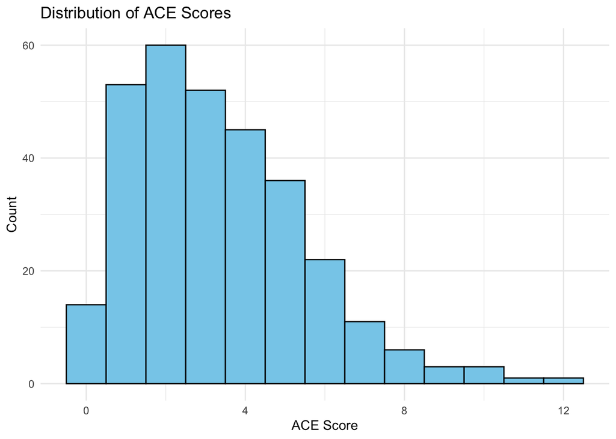

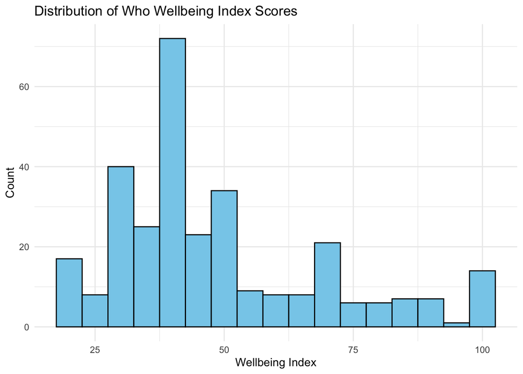

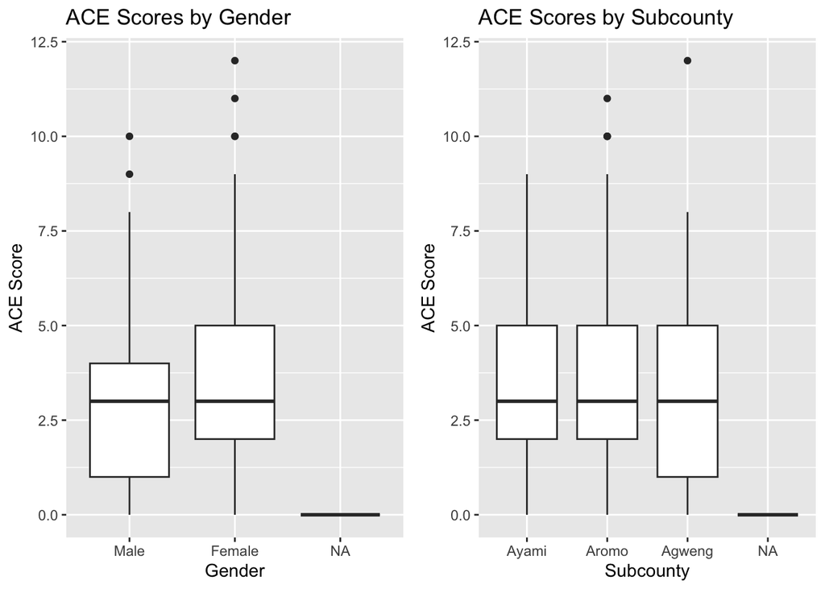

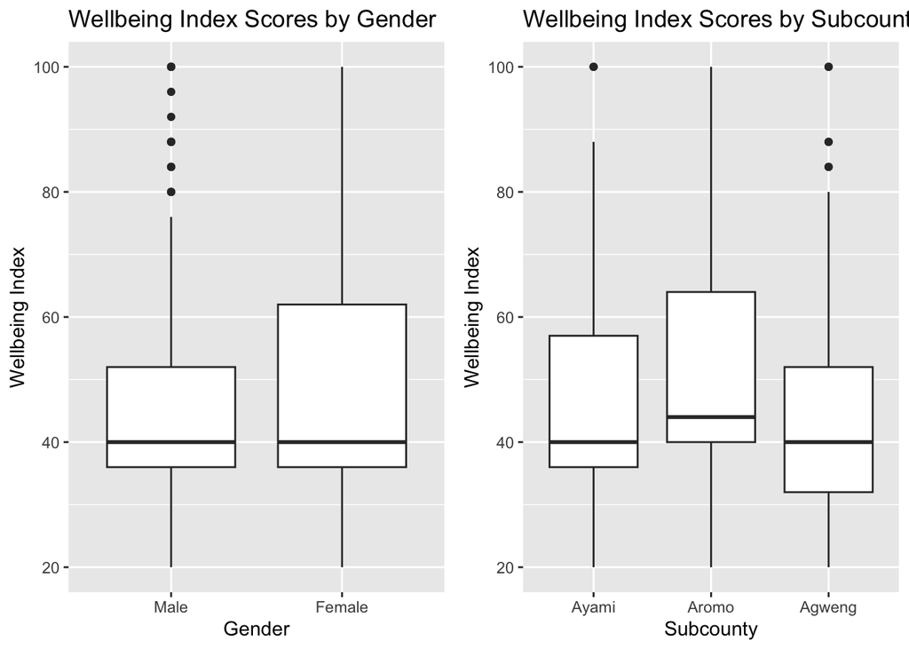

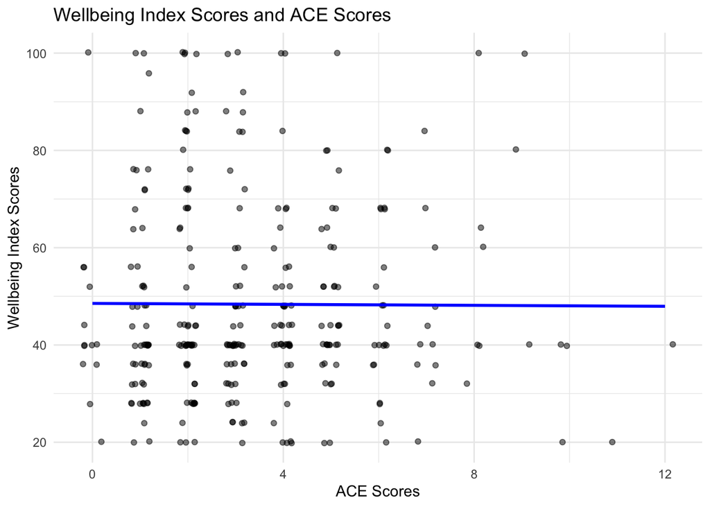

**Conclusions**

The study results indicate that adolescents surveyed throughout Lira District in northern Uganda exhibited poor mental health status. Evaluation of the WHO-5 Wellbeing Index scores found that the majority of scores were low enough to be considered for further clinical screening and treatment for depression.

Nearly half of adolescents surveyed reported ACE-IQ scores of 4 or higher which has had a strong positive association with depression symptom severity and suicidal ideation as well as heavy alcohol consumption among a younger population of emerging adults in Southwestern Uganda. In addition, other studies done in Uganda have found that ACE exposure has also been associated with early initiation of alcohol consumption among youths and alcohol consumption behaviors among adults.

The adolescents surveyed have no living memory of the war, however, they do have memories of the immediate aftermath, have grown up in communities struggling to rebuild post-conflict, and have been raised by parents who most likely suffered directly. High levels of verbal abuse, physical abuse, neglect, and family dysfunction reported are likely in part due to trauma-induced mental health conditions among parents and other caretakers. Poor adolescent wellness scores could also reflect intergenerational trauma, which also places them at increased risk for mental illness and other chronic diseases.

Past international evaluations of mental health have focused on the importance of treatment using Western diagnostic tools and interventions and have failed to address persistent societal determinants, cultural myths, and traditional practices. Mental health response by politically informed analyses and interventions should be a priority focus for building positive adolescent health outcomes.